# Práctica de Aprendizaje No Supervisado

```python
print(ndf.shape)
#preprocessing.scale(ndf)
min_max_scaler = preprocessing.MinMaxScaler()
ndf_lod_tempo = pd.DataFrame(min_max_scaler.fit_transform(ndf[[ "tempo", "loudness"]]), columns=[ "tempo_norm", "loudness_norm"], index=ndf.index.tolist())
ndf = pd.concat([ndf,ndf_lod_tempo], axis=1)
ndf = ndf.drop(["loudness", "tempo", "duration_ms"], axis=1)
#ndf.head()
```

```
(6737, 10)
```

```python
np.isnan(pd.concat([ndf,(ndf_lod_tempo)], axis=1)).sum()
```

```
danceability        0
energy              0
speechiness         0
acousticness        0
instrumentalness    0
liveness            0
valence             0
tempo_norm          0
loudness_norm       0
tempo_norm          0
loudness_norm       0
dtype: int64
```

```python
ndf
```

|  | danceability | energy | speechiness | acousticness | instrumentalness | liveness | valence | tempo_norm | loudness_norm |
| --- | --- | --- | --- | --- | --- | --- | --- | --- | --- |
| 0 | 0.676 | 0.2930 | 0.0366 | 0.845000 | 0.000048 | 0.1170 | 0.3320 | 0.419890 | 0.775762 |
| 1 | 0.242 | 0.2430 | 0.0337 | 0.903000 | 0.000041 | 0.3570 | 0.1520 | 0.546972 | 0.616440 |
| 2 | 0.254 | 0.1540 | 0.0396 | 0.902000 | 0.002290 | 0.1180 | 0.2430 | 0.714668 | 0.688460 |
| 3 | 0.467 | 0.5240 | 0.0547 | 0.614000 | 0.301000 | 0.1550 | 0.6500 | 0.384065 | 0.690388 |
| 4 | 0.582 | 0.6280 | 0.0407 | 0.240000 | 0.000000 | 0.1020 | 0.5300 | 0.500984 | 0.869217 |
| 5 | 0.964 | 0.2750 | 0.0497 | 0.494000 | 0.000003 | 0.0753 | 0.8220 | 0.476305 | 0.683089 |
| 6 | 0.388 | 0.2510 | 0.1310 | 0.622000 | 0.000002 | 0.3540 | 0.2460 | 0.542512 | 0.645883 |
| 7 | 0.650 | 0.4170 | 0.0463 | 0.762000 | 0.405000 | 0.0872 | 0.9240 | 0.321161 | 0.760406 |
| 8 | 0.425 | 0.5700 | 0.0506 | 0.756000 | 0.012500 | 0.2250 | 0.7550 | 0.699916 | 0.743878 |
| 9 | 0.539 | 0.1660 | 0.0611 | 0.913000 | 0.023000 | 0.1120 | 0.3900 | 0.584628 | 0.571007 |
| 10 | 0.718 | 0.4250 | 0.0847 | 0.844000 | 0.000000 | 0.0363 | 0.9520 | 0.444757 | 0.688118 |
| 11 | 0.607 | 0.2810 | 0.0396 | 0.464000 | 0.000002 | 0.2950 | 0.5390 | 0.518701 | 0.685896 |
| 12 | 0.458 | 0.2470 | 0.0429 | 0.823000 | 0.000182 | 0.1210 | 0.3230 | 0.556566 | 0.655233 |
| 13 | 0.319 | 0.1200 | 0.0314 | 0.955000 | 0.949000 | 0.1180 | 0.1670 | 0.541079 | 0.575621 |
| 14 | 0.476 | 0.1960 | 0.0324 | 0.985000 | 0.094600 | 0.1060 | 0.2030 | 0.467578 | 0.668514 |
| 15 | 0.365 | 0.3950 | 0.0283 | 0.666000 | 0.000000 | 0.1150 | 0.1970 | 0.320035 | 0.820585 |
| 16 | 0.203 | 0.9200 | 0.0815 | 0.042300 | 0.484000 | 0.1350 | 0.1890 | 0.378870 | 0.899490 |
| 17 | 0.726 | 0.2880 | 0.0571 | 0.943000 | 0.000000 | 0.1010 | 0.5660 | 0.395158 | 0.764312 |
| 18 | 0.551 | 0.3030 | 0.0390 | 0.732000 | 0.000048 | 0.1900 | 0.6520 | 0.380911 | 0.773297 |
| 19 | 0.673 | 0.2120 | 0.0483 | 0.913000 | 0.773000 | 0.9630 | 0.1780 | 0.444720 | 0.704914 |
| 20 | 0.376 | 0.0808 | 0.0339 | 0.936000 | 0.007110 | 0.1350 | 0.0712 | 0.260970 | 0.562022 |
| 21 | 0.651 | 0.6230 | 0.0296 | 0.346000 | 0.000292 | 0.1660 | 0.9690 | 0.566722 | 0.809770 |
| 22 | 0.423 | 0.3080 | 0.0431 | 0.802000 | 0.000000 | 0.2680 | 0.6670 | 0.636124 | 0.733722 |
| 23 | 0.638 | 0.6130 | 0.0388 | 0.750000 | 0.000000 | 0.2590 | 0.5540 | 0.505119 | 0.899978 |
| 24 | 0.508 | 0.3690 | 0.0306 | 0.631000 | 0.000000 | 0.1200 | 0.1620 | 0.706462 | 0.812553 |
| 25 | 0.402 | 0.0859 | 0.0375 | 0.979000 | 0.001030 | 0.1090 | 0.2740 | 0.304023 | 0.615732 |
| 26 | 0.592 | 0.3290 | 0.0400 | 0.944000 | 0.836000 | 0.0913 | 0.2670 | 0.364936 | 0.695662 |
| 27 | 0.180 | 0.0878 | 0.0454 | 0.887000 | 0.000077 | 0.1080 | 0.1150 | 0.682343 | 0.546422 |
| 28 | 0.511 | 0.7020 | 0.0371 | 0.673000 | 0.000000 | 0.3890 | 0.8520 | 0.480499 | 0.893557 |
| 29 | 0.769 | 0.0615 | 0.0490 | 0.979000 | 0.003040 | 0.4360 | 0.6080 | 0.402542 | 0.437367 |
| ... | ... | ... | ... | ... | ... | ... | ... | ... | ... |
| 6754 | 0.621 | 0.8510 | 0.1340 | 0.020200 | 0.000014 | 0.8870 | 0.4490 | 0.373478 | 0.877371 |
| 6755 | 0.524 | 0.7050 | 0.2210 | 0.484000 | 0.000000 | 0.4540 | 0.3480 | 0.491891 | 0.837602 |
| 6756 | 0.486 | 0.7500 | 0.0427 | 0.269000 | 0.000011 | 0.3250 | 0.3560 | 0.369478 | 0.889358 |
| 6757 | 0.531 | 0.7100 | 0.0920 | 0.038000 | 0.000000 | 0.3360 | 0.3040 | 0.531198 | 0.912404 |
| 6758 | 0.707 | 0.5900 | 0.0301 | 0.010800 | 0.000529 | 0.1070 | 0.0866 | 0.537925 | 0.891287 |
| 6759 | 0.730 | 0.1250 | 0.0451 | 0.961000 | 0.000000 | 0.0905 | 0.3770 | 0.509744 | 0.786187 |
| 6760 | 0.756 | 0.7220 | 0.4660 | 0.000999 | 0.952000 | 0.0668 | 0.1310 | 0.616202 | 0.576915 |
| 6761 | 0.675 | 0.3260 | 0.0361 | 0.915000 | 0.000000 | 0.1060 | 0.2800 | 0.492486 | 0.836405 |
| 6762 | 0.556 | 0.6880 | 0.0856 | 0.061200 | 0.002560 | 0.1120 | 0.4590 | 0.575006 | 0.834159 |
| 6763 | 0.733 | 0.7560 | 0.0465 | 0.007680 | 0.407000 | 0.0930 | 0.1560 | 0.431151 | 0.898538 |
| 6764 | 0.471 | 0.5610 | 0.0287 | 0.554000 | 0.000000 | 0.2050 | 0.3210 | 0.357354 | 0.855008 |
| 6765 | 0.795 | 0.4820 | 0.2200 | 0.234000 | 0.000004 | 0.1040 | 0.0602 | 0.546151 | 0.793462 |
| 6766 | 0.381 | 0.5940 | 0.0486 | 0.348000 | 0.000000 | 0.0925 | 0.2730 | 0.590813 | 0.867313 |
| 6767 | 0.554 | 0.5620 | 0.0316 | 0.242000 | 0.787000 | 0.0919 | 0.6580 | 0.414785 | 0.736310 |
| 6768 | 0.759 | 0.3450 | 0.0975 | 0.188000 | 0.006980 | 0.2090 | 0.3440 | 0.402616 | 0.624545 |
| 6769 | 0.823 | 0.4950 | 0.0491 | 0.257000 | 0.915000 | 0.0805 | 0.3870 | 0.468268 | 0.729865 |
| 6770 | 0.536 | 0.7210 | 0.3860 | 0.062000 | 0.000000 | 0.8240 | 0.3930 | 0.481074 | 0.855838 |
| 6771 | 0.802 | 0.7170 | 0.0834 | 0.079700 | 0.450000 | 0.2490 | 0.5660 | 0.575125 | 0.736554 |
| 6772 | 0.543 | 0.6490 | 0.2460 | 0.026900 | 0.000000 | 0.0722 | 0.6590 | 0.379971 | 0.877371 |
| 6773 | 0.717 | 0.5160 | 0.0601 | 0.079400 | 0.000000 | 0.1640 | 0.2580 | 0.521678 | 0.855204 |
| 6774 | 0.762 | 0.3990 | 0.0634 | 0.123000 | 0.333000 | 0.0927 | 0.0526 | 0.533802 | 0.771490 |
| 6775 | 0.788 | 0.6720 | 0.0414 | 0.016900 | 0.000000 | 0.0501 | 0.4160 | 0.542138 | 0.847367 |
| 6776 | 0.836 | 0.3490 | 0.0444 | 0.000696 | 0.230000 | 0.0773 | 0.4170 | 0.390226 | 0.601548 |
| 6777 | 0.724 | 0.6280 | 0.0962 | 0.409000 | 0.000000 | 0.1050 | 0.5240 | 0.410267 | 0.910061 |
| 6778 | 0.638 | 0.9240 | 0.0359 | 0.002050 | 0.000173 | 0.1490 | 0.5290 | 0.459948 | 0.918166 |
| 6779 | 0.471 | 0.4890 | 0.0263 | 0.709000 | 0.000001 | 0.1200 | 0.1840 | 0.622000 | 0.836015 |
| 6780 | 0.471 | 0.4890 | 0.0263 | 0.709000 | 0.000001 | 0.1200 | 0.1840 | 0.622000 | 0.836015 |
| 6781 | 0.795 | 0.4580 | 0.0929 | 0.225000 | 0.000000 | 0.1130 | 0.3310 | 0.504869 | 0.853983 |
| 6782 | 0.639 | 0.5130 | 0.0475 | 0.318000 | 0.907000 | 0.1900 | 0.0617 | 0.657020 | 0.745636 |
| 6783 | 0.647 | 0.8230 | 0.0762 | 0.059800 | 0.000000 | 0.1190 | 0.3960 | 0.410411 | 0.885354 |

6737 rows × 9 columns

```python
ndf = ndf.loc[ (np.isnan(ndf.tempo_norm)) != True, :]
```

```python
print(ndf.columns)
print(ndf.describe())
```

```
Index(['danceability', 'energy', 'speechiness', 'acousticness',
       'instrumentalness', 'liveness', 'valence', 'tempo_norm',
       'loudness_norm'],
      dtype='object')
       danceability       energy  speechiness  acousticness  instrumentalness  \
count   6737.000000  6737.000000  6737.000000   6737.000000       6737.000000
mean       0.599119     0.562467     0.069448      0.354709          0.093561
std        0.163068     0.228097     0.081816      0.326742          0.242197
min        0.000000     0.003770     0.000000      0.000002          0.000000
25%        0.490000     0.391000     0.032200      0.052200          0.000000
50%        0.615000     0.574000     0.041300      0.248000          0.000021
75%        0.718000     0.747000     0.065000      0.638000          0.004180
max        0.991000     0.997000     0.959000      0.996000          0.988000

          liveness      valence   tempo_norm  loudness_norm
count  6737.000000  6737.000000  6737.000000    6737.000000
mean      0.204706     0.578796     0.485464       0.779836
std       0.190674     0.252190     0.117574       0.101750
min       0.009670     0.000000     0.000000       0.000000
25%       0.091500     0.376000     0.399618       0.720856
50%       0.128000     0.597000     0.479073       0.792925
75%       0.252000     0.794000     0.546611       0.854471
max       0.997000     1.000000     1.000000       1.000000
```

## *k*-means

K-means es un técnica de machine learning en que consiste en separar los individuos y agruparlos en cluster alrededor de un centro cuya distancia en valor media sea más cercano.

Ahora bien: ¿Como elegir el K? bueno nuestro dataset segun hemos señalado son datos de música por lo que nuestra suposicion inicicial es que el algoritmo agrupara por canciones con sonidos/metricas similares o lo que es lo mismo canciones del mismo genero, según https://en.wikipedia.org/wiki/List_of_popular_music_genres existen alrededor de 16 generos musicales principales, sin embargo como las canciones seleccionadas son de la lista billboard de USA, reduciremos las lista a unos 10 generos a saber:

1. Blues
2. Rock/Metal
3. Pop
4. Country
5. R&B
6. Electronic
7. Rock
8. Hip hop/Rap
9. Jazz
10. Latin

```python
from sklearn.cluster import KMeans
kmeans = KMeans(n_clusters=10)
```

Examinemos visualmente el resultado, también gráficaremos los centros de los cluster, según lo determinado por el algoritmo

```
[ 0.41695809  0.17100479]
```

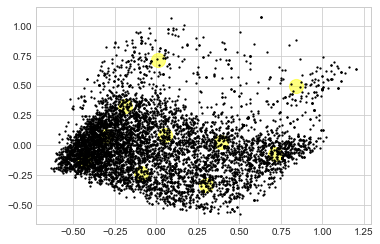

```python
from sklearn.decomposition import PCA
#pca = PCA(n_components=17).fit(ndf)
reduced_data = PCA(n_components=2).fit_transform(ndf)
print( PCA(n_components=2).fit(ndf).explained_variance_ratio_)
kmeans.fit(reduced_data)
plt.plot(reduced_data[:, 0], reduced_data[:, 1], 'k.', markersize=2.5)
centers = kmeans.cluster_centers_
plt.scatter(centers[:, 0], centers[:, 1], c='yellow', s=200, alpha=0.5);
```

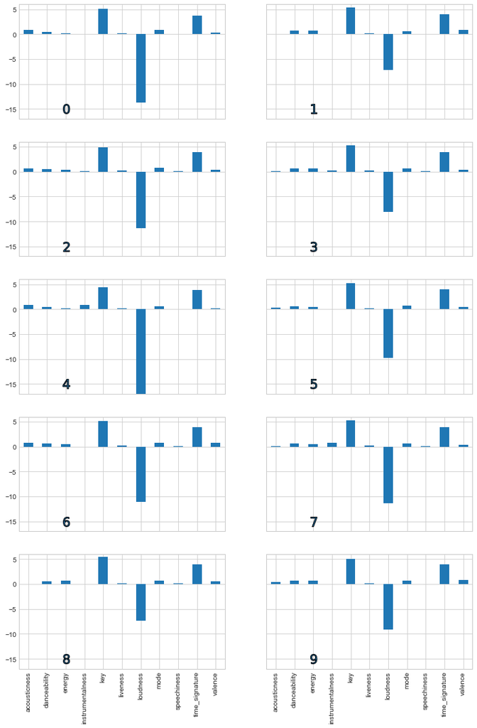

```python
labels = kmeans.labels_

#Glue back to originaal data
def plot_center_cluster(songs, labels, nf, nc,list_x = [9,10], list_y =[1,3,5,7,9], fy= 18, fx = 12 ):
    songs['clusters'] = labels

    #Add the column into our list
    #clmns.extend(['clusters'])
    plt.figure(figsize=(fx,fy))
    #Lets analyze the clusters
    #print (songs.loc[:, :].groupby(['clusters']).mean())
    groups_songs = songs[songs.columns.difference(['duration_ms', 'year', 'rank', 'tempo'])].groupby(['clusters']).mean()
    #fig = plt.figure()
    #axes = fig.subplots(nrows=4, ncols=2)
    ng=1
    j = 0
    for group in groups_songs.iterrows():
        #print((group[1]))

        plt.subplot(nf, nc,ng )
        #plt.xlim(0,1)
        plt.ylim(-17,6)

    # Not ticks everywhere
        if ng not in list_x :
            plt.tick_params(labelbottom='off')
        if ng not in list_y :
            plt.tick_params(labelleft='off')
        if ng < nf*nc:
            ng +=1
        ax =group[1].plot.bar()
        ax.scatter(2, -15, marker='$%d$' % (j), alpha=1,  s=200, edgecolor='black')
        j +=1
    plt.show()
plot_center_cluster(songs, labels, 5, 2)
```

```python
songs.loc[songs.clusters ==9,:]
```

|  | year | rank | song | singer | danceability | energy | key | loudness | mode | speechiness | ... | valence | tempo | type | id | uri | track_href | analysis_url | duration_ms | time_signature | clusters |
| --- | --- | --- | --- | --- | --- | --- | --- | --- | --- | --- | --- | --- | --- | --- | --- | --- | --- | --- | --- | --- | --- |
| 5 | 1940 | 6 | Swinging On A Star | Bing Crosby | 0.964 | 0.275 | 10 | -13.516 | 1 | 0.0497 | ... | 0.822 | 115.978 | audio_features | 1Gelr53RPFzaIwGSPNbqlT | spotify:track:1Gelr53RPFzaIwGSPNbqlT | https://api.spotify.com/v1/tracks/1Gelr53RPFza... | https://api.spotify.com/v1/audio-analysis/1Gel... | 176480 | 4 | 9 |
| 21 | 1940 | 22 | Brazil | Xavier Cugat Jimmy Dorsey (Bob Eberly &amp; ... | 0.651 | 0.623 | 4 | -8.327 | 0 | 0.0296 | ... | 0.969 | 137.994 | audio_features | 2eKrf3Sv8PReqlcYanNYii | spotify:track:2eKrf3Sv8PReqlcYanNYii | https://api.spotify.com/v1/tracks/2eKrf3Sv8PRe... | https://api.spotify.com/v1/audio-analysis/2eKr... | 110237 | 4 | 9 |
| 28 | 1940 | 29 | This Land Is Your Land | Woody Guthrie | 0.511 | 0.702 | 7 | -4.895 | 1 | 0.0371 | ... | 0.852 | 116.999 | audio_features | 6iLHSfrDwcdhVeyV3WXDBn | spotify:track:6iLHSfrDwcdhVeyV3WXDBn | https://api.spotify.com/v1/tracks/6iLHSfrDwcdh... | https://api.spotify.com/v1/audio-analysis/6iLH... | 295613 | 4 | 9 |
| 50 | 1940 | 51 | Rum And Coca-Cola | Andrews Sisters | 0.779 | 0.633 | 10 | -4.783 | 1 | 0.1360 | ... | 0.884 | 80.076 | audio_features | 6wXR0IunPIfcvd6ASl9SDn | spotify:track:6wXR0IunPIfcvd6ASl9SDn | https://api.spotify.com/v1/tracks/6wXR0IunPIfc... | https://api.spotify.com/v1/audio-analysis/6wXR... | 218533 | 4 | 9 |
| 51 | 1940 | 52 | The Breeze And I | Jimmy Dorsey (Bob Eberly) | 0.524 | 0.472 | 4 | -12.466 | 1 | 0.0320 | ... | 0.775 | 130.444 | audio_features | 2ynAsq3MTsVlRtgg79xzek | spotify:track:2ynAsq3MTsVlRtgg79xzek | https://api.spotify.com/v1/tracks/2ynAsq3MTsVl... | https://api.spotify.com/v1/audio-analysis/2ynA... | 169493 | 4 | 9 |
| 77 | 1940 | 78 | Smoke! Smoke! Smoke! (That Cigarette) | Tex Williams | 0.828 | 0.446 | 6 | -17.715 | 0 | 0.1010 | ... | 0.971 | 125.940 | audio_features | 0UDytqREuzv0rDTBq7NNID | spotify:track:0UDytqREuzv0rDTBq7NNID | https://api.spotify.com/v1/tracks/0UDytqREuzv0... | https://api.spotify.com/v1/audio-analysis/0UDy... | 159053 | 4 | 9 |
| 86 | 1940 | 87 | Chattanoogie Shoe Shine Boy | Red Foley | 0.616 | 0.599 | 10 | -8.151 | 1 | 0.0661 | ... | 0.653 | 150.192 | audio_features | 1MkRymdAdXl0h3LUhrUR5S | spotify:track:1MkRymdAdXl0h3LUhrUR5S | https://api.spotify.com/v1/tracks/1MkRymdAdXl0... | https://api.spotify.com/v1/audio-analysis/1MkR... | 164565 | 4 | 9 |
| 94 | 1940 | 95 | Jersey Bounce | Benny Goodman Jimmy Dorsey | 0.708 | 0.555 | 0 | -10.915 | 1 | 0.0335 | ... | 0.622 | 97.950 | audio_features | 1lKSgSmv9ZrcKVKUzJtlAT | spotify:track:1lKSgSmv9ZrcKVKUzJtlAT | https://api.spotify.com/v1/tracks/1lKSgSmv9Zrc... | https://api.spotify.com/v1/audio-analysis/1lKS... | 531293 | 4 | 9 |
| 97 | 1940 | 98 | You Call Everybody Darlin’ | Al Trace Andrews Sisters Anne Vincent | 0.630 | 0.492 | 6 | -11.616 | 1 | 0.0428 | ... | 0.970 | 118.271 | audio_features | 2yRiJpbzFYQu0CLc9xLcga | spotify:track:2yRiJpbzFYQu0CLc9xLcga | https://api.spotify.com/v1/tracks/2yRiJpbzFYQu... | https://api.spotify.com/v1/audio-analysis/2yRi... | 86987 | 4 | 9 |
| 192 | 1942 | 13 | Jersey Bounce | Benny Goodman and His Orchestra | 0.708 | 0.555 | 0 | -10.915 | 1 | 0.0335 | ... | 0.622 | 97.950 | audio_features | 1lKSgSmv9ZrcKVKUzJtlAT | spotify:track:1lKSgSmv9ZrcKVKUzJtlAT | https://api.spotify.com/v1/tracks/1lKSgSmv9Zrc... | https://api.spotify.com/v1/audio-analysis/1lKS... | 531293 | 4 | 9 |
| 206 | 1942 | 27 | Remember Pearl Harbor | Swing and Sway with Sammy Kaye | 0.695 | 0.552 | 8 | -12.778 | 1 | 0.0363 | ... | 0.956 | 138.907 | audio_features | 5L657yDM77IYR0G7UO8vMJ | spotify:track:5L657yDM77IYR0G7UO8vMJ | https://api.spotify.com/v1/tracks/5L657yDM77IY... | https://api.spotify.com/v1/audio-analysis/5L65... | 145913 | 4 | 9 |
| 218 | 1942 | 39 | Take Me | Tommy Dorsey and His Orchestra | 0.660 | 0.485 | 2 | -8.101 | 1 | 0.0258 | ... | 0.829 | 99.828 | audio_features | 1oV1tu8utgHQjLJsEK9sVl | spotify:track:1oV1tu8utgHQjLJsEK9sVl | https://api.spotify.com/v1/tracks/1oV1tu8utgHQ... | https://api.spotify.com/v1/audio-analysis/1oV1... | 302520 | 4 | 9 |
| 238 | 1942 | 59 | Tonight We Love | Freddy Martin and His Orchestra | 0.600 | 0.797 | 3 | -6.830 | 0 | 0.0353 | ... | 0.813 | 97.029 | audio_features | 6AadIowbJGI2Xhzknv5Are | spotify:track:6AadIowbJGI2Xhzknv5Are | https://api.spotify.com/v1/tracks/6AadIowbJGI2... | https://api.spotify.com/v1/audio-analysis/6Aad... | 301027 | 4 | 9 |
| 246 | 1942 | 67 | Jersey Bounce | Jimmy Dorsey and His Orchestra | 0.708 | 0.555 | 0 | -10.915 | 1 | 0.0335 | ... | 0.622 | 97.950 | audio_features | 1lKSgSmv9ZrcKVKUzJtlAT | spotify:track:1lKSgSmv9ZrcKVKUzJtlAT | https://api.spotify.com/v1/tracks/1lKSgSmv9Zrc... | https://api.spotify.com/v1/audio-analysis/1lKS... | 531293 | 4 | 9 |
| 253 | 1942 | 74 | Take Me | Benny Goodman and His Orchestra | 0.660 | 0.485 | 2 | -8.101 | 1 | 0.0258 | ... | 0.829 | 99.828 | audio_features | 1oV1tu8utgHQjLJsEK9sVl | spotify:track:1oV1tu8utgHQjLJsEK9sVl | https://api.spotify.com/v1/tracks/1oV1tu8utgHQ... | https://api.spotify.com/v1/audio-analysis/1oV1... | 302520 | 4 | 9 |
| 296 | 1943 | 19 | Boogie Woogie | Tommy Dorsey | 0.646 | 0.521 | 6 | -9.469 | 1 | 0.0921 | ... | 0.732 | 77.418 | audio_features | 27tBqDP2bmQyFGqz0KBbFO | spotify:track:27tBqDP2bmQyFGqz0KBbFO | https://api.spotify.com/v1/tracks/27tBqDP2bmQy... | https://api.spotify.com/v1/audio-analysis/27tB... | 145914 | 4 | 9 |
| 316 | 1943 | 39 | Brazil | Xavier Cugat | 0.651 | 0.623 | 4 | -8.327 | 0 | 0.0296 | ... | 0.969 | 137.994 | audio_features | 2eKrf3Sv8PReqlcYanNYii | spotify:track:2eKrf3Sv8PReqlcYanNYii | https://api.spotify.com/v1/tracks/2eKrf3Sv8PRe... | https://api.spotify.com/v1/audio-analysis/2eKr... | 110237 | 4 | 9 |
| 318 | 1944 | 1 | Swinging On A Star | Bing Crosby | 0.964 | 0.275 | 10 | -13.516 | 1 | 0.0497 | ... | 0.822 | 115.978 | audio_features | 1Gelr53RPFzaIwGSPNbqlT | spotify:track:1Gelr53RPFzaIwGSPNbqlT | https://api.spotify.com/v1/tracks/1Gelr53RPFza... | https://api.spotify.com/v1/audio-analysis/1Gel... | 176480 | 4 | 9 |
| 326 | 1944 | 9 | My Heart Tells Me | Glen Gray | 0.719 | 0.714 | 5 | -6.199 | 0 | 0.0443 | ... | 0.909 | 99.983 | audio_features | 5uCRyoRxyTuqKrKD5KoclL | spotify:track:5uCRyoRxyTuqKrKD5KoclL | https://api.spotify.com/v1/tracks/5uCRyoRxyTuq... | https://api.spotify.com/v1/audio-analysis/5uCR... | 280187 | 4 | 9 |
| 360 | 1945 | 1 | The Andrews Sisters | Rum & Coca-Cola | 0.748 | 0.277 | 10 | -14.164 | 1 | 0.3280 | ... | 0.836 | 161.221 | audio_features | 0oJaagIpUV8yiAiE5YBmV9 | spotify:track:0oJaagIpUV8yiAiE5YBmV9 | https://api.spotify.com/v1/tracks/0oJaagIpUV8y... | https://api.spotify.com/v1/audio-analysis/0oJa... | 184467 | 4 | 9 |
| 361 | 1945 | 2 | Les Brown | Sentimental Journey | 0.748 | 0.277 | 10 | -14.164 | 1 | 0.3280 | ... | 0.836 | 161.221 | audio_features | 0oJaagIpUV8yiAiE5YBmV9 | spotify:track:0oJaagIpUV8yiAiE5YBmV9 | https://api.spotify.com/v1/tracks/0oJaagIpUV8y... | https://api.spotify.com/v1/audio-analysis/0oJa... | 184467 | 4 | 9 |
| 582 | 1949 | 9 | Frankie Laine | Mule Train | 0.724 | 0.646 | 4 | -11.606 | 1 | 0.0349 | ... | 0.854 | 142.657 | audio_features | 5NzlQd1abCkPYSTKttTijU | spotify:track:5NzlQd1abCkPYSTKttTijU | https://api.spotify.com/v1/tracks/5NzlQd1abCkP... | https://api.spotify.com/v1/audio-analysis/5Nzl... | 154213 | 4 | 9 |
| 626 | 1950 | 23 | Ames Brothers | Rag Mop | 0.590 | 0.468 | 7 | -9.679 | 1 | 0.0788 | ... | 0.978 | 201.017 | audio_features | 5NhriNwwXptfNB10PJ22dT | spotify:track:5NhriNwwXptfNB10PJ22dT | https://api.spotify.com/v1/tracks/5NhriNwwXptf... | https://api.spotify.com/v1/audio-analysis/5Nhr... | 160586 | 4 | 9 |
| 633 | 1950 | 30 | Frankie Laine | Cry Of The Wild Goose | 0.574 | 0.500 | 11 | -9.870 | 1 | 0.0354 | ... | 0.859 | 77.461 | audio_features | 4c5SQiPpwZKPs1YXm7ms0u | spotify:track:4c5SQiPpwZKPs1YXm7ms0u | https://api.spotify.com/v1/tracks/4c5SQiPpwZKP... | https://api.spotify.com/v1/audio-analysis/4c5S... | 172520 | 4 | 9 |
| 634 | 1951 | 1 | Nat King Cole | Too Young | 0.574 | 0.500 | 11 | -9.870 | 1 | 0.0354 | ... | 0.859 | 77.461 | audio_features | 4c5SQiPpwZKPs1YXm7ms0u | spotify:track:4c5SQiPpwZKPs1YXm7ms0u | https://api.spotify.com/v1/tracks/4c5SQiPpwZKP... | https://api.spotify.com/v1/audio-analysis/4c5S... | 172520 | 4 | 9 |
| 674 | 1952 | 11 | Georgia Gibbs | Kiss Of Fire | 0.576 | 0.872 | 5 | -8.673 | 0 | 0.0689 | ... | 0.592 | 129.584 | audio_features | 4Hatk2WuUVNYCPlQNU3IfF | spotify:track:4Hatk2WuUVNYCPlQNU3IfF | https://api.spotify.com/v1/tracks/4Hatk2WuUVNY... | https://api.spotify.com/v1/audio-analysis/4Hat... | 154093 | 4 | 9 |
| 756 | 1955 | 3 | Mitch Miller | The Yellow Rose Of Texas | 0.750 | 0.873 | 8 | -10.846 | 1 | 0.0385 | ... | 0.877 | 99.696 | audio_features | 7rGNXbpYxdwRYiw4sRcOoj | spotify:track:7rGNXbpYxdwRYiw4sRcOoj | https://api.spotify.com/v1/tracks/7rGNXbpYxdwR... | https://api.spotify.com/v1/audio-analysis/7rGN... | 180467 | 4 | 9 |
| 757 | 1955 | 4 | Roger Williams | Autumn Leaves | 0.750 | 0.873 | 8 | -10.846 | 1 | 0.0385 | ... | 0.877 | 99.696 | audio_features | 7rGNXbpYxdwRYiw4sRcOoj | spotify:track:7rGNXbpYxdwRYiw4sRcOoj | https://api.spotify.com/v1/tracks/7rGNXbpYxdwR... | https://api.spotify.com/v1/audio-analysis/7rGN... | 180467 | 4 | 9 |
| 762 | 1955 | 9 | Pat Boone | Ain’t That A Shame | 0.693 | 0.591 | 10 | -5.249 | 1 | 0.0317 | ... | 0.830 | 116.826 | audio_features | 6pTybvSMcw5spOS7d656rn | spotify:track:6pTybvSMcw5spOS7d656rn | https://api.spotify.com/v1/tracks/6pTybvSMcw5s... | https://api.spotify.com/v1/audio-analysis/6pTy... | 143893 | 4 | 9 |
| 768 | 1955 | 15 | Fontaine Sisters | Hearts Of Stone | 0.655 | 0.710 | 5 | -5.120 | 1 | 0.0556 | ... | 0.967 | 173.006 | audio_features | 0BkL9j4csYOLAl4n7C7tyl | spotify:track:0BkL9j4csYOLAl4n7C7tyl | https://api.spotify.com/v1/tracks/0BkL9j4csYOL... | https://api.spotify.com/v1/audio-analysis/0BkL... | 125852 | 4 | 9 |
| ... | ... | ... | ... | ... | ... | ... | ... | ... | ... | ... | ... | ... | ... | ... | ... | ... | ... | ... | ... | ... | ... |
| 5850 | 2006 | 67 | Ray J | One Wish | 0.525 | 0.652 | 5 | -7.042 | 0 | 0.2800 | ... | 0.602 | 127.673 | audio_features | 5qrzhg9Fmu8Amg2uMhHfe5 | spotify:track:5qrzhg9Fmu8Amg2uMhHfe5 | https://api.spotify.com/v1/tracks/5qrzhg9Fmu8A... | https://api.spotify.com/v1/audio-analysis/5qrz... | 337640 | 4 | 9 |
| 5880 | 2006 | 97 | Gorillaz | Feel Good Inc | 0.859 | 0.739 | 6 | -6.825 | 1 | 0.0645 | ... | 0.878 | 138.301 | audio_features | 55UWXUtvtXi2Meod3CYBbu | spotify:track:55UWXUtvtXi2Meod3CYBbu | https://api.spotify.com/v1/tracks/55UWXUtvtXi2... | https://api.spotify.com/v1/audio-analysis/55UW... | 202497 | 4 | 9 |
| 5885 | 2007 | 2 | Rihanna feat. Jay-Z | Umbrella | 0.640 | 0.805 | 6 | -2.439 | 0 | 0.0454 | ... | 0.764 | 168.018 | audio_features | 37Q8nitj3hsY7IH5ATnTEX | spotify:track:37Q8nitj3hsY7IH5ATnTEX | https://api.spotify.com/v1/tracks/37Q8nitj3hsY... | https://api.spotify.com/v1/audio-analysis/37Q8... | 217182 | 4 | 9 |
| 5899 | 2007 | 16 | Mims | This Is Why I’m Hot | 0.568 | 0.608 | 8 | -4.275 | 1 | 0.5600 | ... | 0.577 | 79.925 | audio_features | 27SlYHLudzuu8UcQDvKIGV | spotify:track:27SlYHLudzuu8UcQDvKIGV | https://api.spotify.com/v1/tracks/27SlYHLudzuu... | https://api.spotify.com/v1/audio-analysis/27Sl... | 217613 | 4 | 9 |
| 5906 | 2007 | 23 | Gym Class Heroes feat. Patrick Stump | Cupid’s Chokehold/Breakfast In America | 0.666 | 0.711 | 1 | -4.227 | 0 | 0.0750 | ... | 0.884 | 79.755 | audio_features | 2Lhdl74nwwVGOE2Gv35QuK | spotify:track:2Lhdl74nwwVGOE2Gv35QuK | https://api.spotify.com/v1/tracks/2Lhdl74nwwVG... | https://api.spotify.com/v1/audio-analysis/2Lhd... | 236880 | 4 | 9 |
| 5918 | 2007 | 35 | Ludacris feat. Mary J. Blige | Runaway Love | 0.405 | 0.721 | 1 | -6.970 | 1 | 0.2840 | ... | 0.816 | 92.855 | audio_features | 3liD1gxb1LAy2ccADcY70o | spotify:track:3liD1gxb1LAy2ccADcY70o | https://api.spotify.com/v1/tracks/3liD1gxb1LAy... | https://api.spotify.com/v1/audio-analysis/3liD... | 280680 | 4 | 9 |
| 5924 | 2007 | 41 | Elliott Yamin | Wait For You | 0.688 | 0.875 | 0 | -4.960 | 1 | 0.1170 | ... | 0.847 | 92.541 | audio_features | 7pV175xJfRkBLJkvN02mk9 | spotify:track:7pV175xJfRkBLJkvN02mk9 | https://api.spotify.com/v1/tracks/7pV175xJfRkB... | https://api.spotify.com/v1/audio-analysis/7pV1... | 211160 | 4 | 9 |
| 5931 | 2007 | 48 | Robin Thicke | Lost Without U | 0.887 | 0.362 | 0 | -12.083 | 1 | 0.0947 | ... | 0.843 | 113.211 | audio_features | 2jr9zgdUapPf0f6QRYAmzX | spotify:track:2jr9zgdUapPf0f6QRYAmzX | https://api.spotify.com/v1/tracks/2jr9zgdUapPf... | https://api.spotify.com/v1/audio-analysis/2jr9... | 254200 | 5 | 9 |
| 5962 | 2007 | 79 | Paula DeAnda feat. The DEY | Walk Away (Remember Me) | 0.755 | 0.311 | 0 | -13.522 | 1 | 0.1970 | ... | 0.816 | 77.987 | audio_features | 38BiBV7lzQO1FS99Nh8Pxw | spotify:track:38BiBV7lzQO1FS99Nh8Pxw | https://api.spotify.com/v1/tracks/38BiBV7lzQO1... | https://api.spotify.com/v1/audio-analysis/38Bi... | 209979 | 4 | 9 |
| 5983 | 2007 | 100 | R. Kelly and Usher | Same Girl | 0.798 | 0.498 | 6 | -9.477 | 1 | 0.3360 | ... | 0.745 | 139.890 | audio_features | 4hPFLkCkCzdqTZ7OJxKl4A | spotify:track:4hPFLkCkCzdqTZ7OJxKl4A | https://api.spotify.com/v1/tracks/4hPFLkCkCzdq... | https://api.spotify.com/v1/audio-analysis/4hPF... | 251327 | 4 | 9 |
| 5994 | 2008 | 11 | Ray J and Yung Berg | Sexy Can I | 0.575 | 0.686 | 1 | -6.008 | 1 | 0.3190 | ... | 0.925 | 172.132 | audio_features | 6zF96W2EXWc10w0I2Wd0DI | spotify:track:6zF96W2EXWc10w0I2Wd0DI | https://api.spotify.com/v1/tracks/6zF96W2EXWc1... | https://api.spotify.com/v1/audio-analysis/6zF9... | 204040 | 4 | 9 |
| 6013 | 2008 | 30 | Jordin Sparks | Tattoo | 0.564 | 0.838 | 2 | -2.393 | 1 | 0.0404 | ... | 0.553 | 167.954 | audio_features | 0eIfBjs1pMiRNkbngEATQi | spotify:track:0eIfBjs1pMiRNkbngEATQi | https://api.spotify.com/v1/tracks/0eIfBjs1pMiR... | https://api.spotify.com/v1/audio-analysis/0eIf... | 232920 | 4 | 9 |
| 6022 | 2008 | 39 | Estelle feat. Kanye West | American Boy | 0.769 | 0.659 | 4 | -6.490 | 0 | 0.3040 | ... | 0.585 | 117.872 | audio_features | 2mLDD3k9WA57OBCQze8ZgM | spotify:track:2mLDD3k9WA57OBCQze8ZgM | https://api.spotify.com/v1/tracks/2mLDD3k9WA57... | https://api.spotify.com/v1/audio-analysis/2mLD... | 288941 | 4 | 9 |
| 6045 | 2008 | 62 | Rihanna feat. Ne-Yo | Hate That I Love You | 0.699 | 0.738 | 5 | -11.632 | 0 | 0.0537 | ... | 0.815 | 95.019 | audio_features | 1vj0w449Q10sIFytvAXTsO | spotify:track:1vj0w449Q10sIFytvAXTsO | https://api.spotify.com/v1/tracks/1vj0w449Q10s... | https://api.spotify.com/v1/audio-analysis/1vj0... | 227053 | 4 | 9 |
| 6046 | 2008 | 63 | Lupe Fiasco feat. Matthew Santos | Superstar | 0.699 | 0.738 | 5 | -11.632 | 0 | 0.0537 | ... | 0.815 | 95.019 | audio_features | 1vj0w449Q10sIFytvAXTsO | spotify:track:1vj0w449Q10sIFytvAXTsO | https://api.spotify.com/v1/tracks/1vj0w449Q10s... | https://api.spotify.com/v1/audio-analysis/1vj0... | 227053 | 4 | 9 |
| 6111 | 2009 | 28 | Kid Cudi | Day ‘n’ Nite | 0.883 | 0.440 | 11 | -6.393 | 0 | 0.0642 | ... | 0.836 | 138.015 | audio_features | 44qLufbWma2pxvvfnmTYIC | spotify:track:44qLufbWma2pxvvfnmTYIC | https://api.spotify.com/v1/tracks/44qLufbWma2p... | https://api.spotify.com/v1/audio-analysis/44qL... | 221267 | 4 | 9 |
| 6114 | 2009 | 31 | Jay-Z, Rihanna and Kanye West | Run This Town | 0.537 | 0.729 | 0 | -7.835 | 0 | 0.3810 | ... | 0.554 | 170.314 | audio_features | 68kfENR5llX3UDuIEB7yvE | spotify:track:68kfENR5llX3UDuIEB7yvE | https://api.spotify.com/v1/tracks/68kfENR5llX3... | https://api.spotify.com/v1/audio-analysis/68kf... | 272494 | 4 | 9 |
| 6147 | 2009 | 64 | Shakira | She Wolf | 0.872 | 0.725 | 5 | -5.108 | 0 | 0.0827 | ... | 0.687 | 137.937 | audio_features | 2ZLkmFeraZyt2ccuwnupny | spotify:track:2ZLkmFeraZyt2ccuwnupny | https://api.spotify.com/v1/tracks/2ZLkmFeraZyt... | https://api.spotify.com/v1/audio-analysis/2ZLk... | 192693 | 4 | 9 |
| 6207 | 2010 | 24 | Eminem | Not Afraid | 0.851 | 0.950 | 0 | -1.097 | 0 | 0.2690 | ... | 0.679 | 114.661 | audio_features | 7Ie9W94M7OjPoZVV216Xus | spotify:track:7Ie9W94M7OjPoZVV216Xus | https://api.spotify.com/v1/tracks/7Ie9W94M7OjP... | https://api.spotify.com/v1/audio-analysis/7Ie9... | 248133 | 5 | 9 |
| 6272 | 2010 | 89 | Sean Kingston and Justin Bieber | Eenie Meenie | 0.812 | 0.508 | 1 | -7.640 | 1 | 0.0726 | ... | 0.885 | 121.162 | audio_features | 0NhBAfdjckhMiVLGn0BSik | spotify:track:0NhBAfdjckhMiVLGn0BSik | https://api.spotify.com/v1/tracks/0NhBAfdjckhM... | https://api.spotify.com/v1/audio-analysis/0NhB... | 201927 | 4 | 9 |
| 6326 | 2011 | 43 | Jason Aldean | Dirt Road Anthem | 0.679 | 0.763 | 2 | -4.998 | 1 | 0.0384 | ... | 0.605 | 127.049 | audio_features | 2IwHeEXuzlQKblUzvVKMKC | spotify:track:2IwHeEXuzlQKblUzvVKMKC | https://api.spotify.com/v1/tracks/2IwHeEXuzlQK... | https://api.spotify.com/v1/audio-analysis/2IwH... | 224960 | 4 | 9 |
| 6363 | 2011 | 80 | Zac Brown Band feat. Jimmy Buffett | Knee Deep | 0.715 | 0.584 | 8 | -8.231 | 1 | 0.0296 | ... | 0.610 | 90.987 | audio_features | 1yEwEiTpsaPhQi9lb5EVV4 | spotify:track:1yEwEiTpsaPhQi9lb5EVV4 | https://api.spotify.com/v1/tracks/1yEwEiTpsaPh... | https://api.spotify.com/v1/audio-analysis/1yEw... | 203173 | 4 | 9 |
| 6384 | 2012 | 1 | Gotye feat. Kimbra | Somebody That I Used To Know | 0.833 | 0.322 | 2 | -8.178 | 0 | 0.0386 | ... | 0.724 | 128.917 | audio_features | 7ycx4JIETwU5qrfxQyGbKc | spotify:track:7ycx4JIETwU5qrfxQyGbKc | https://api.spotify.com/v1/tracks/7ycx4JIETwU5... | https://api.spotify.com/v1/audio-analysis/7ycx... | 243850 | 4 | 9 |
| 6447 | 2012 | 64 | Adele | Rumour Has It | 0.618 | 0.753 | 7 | -5.050 | 0 | 0.0451 | ... | 0.557 | 120.041 | audio_features | 76N7FdzCI9OsiUnzJVLY2m | spotify:track:76N7FdzCI9OsiUnzJVLY2m | https://api.spotify.com/v1/tracks/76N7FdzCI9Os... | https://api.spotify.com/v1/audio-analysis/76N7... | 221427 | 4 | 9 |
| 6472 | 2012 | 89 | Rihanna | You Da One | 0.711 | 0.689 | 8 | -5.351 | 1 | 0.0462 | ... | 0.866 | 127.046 | audio_features | 2lx2uATZ8VTb5257DYXXXD | spotify:track:2lx2uATZ8VTb5257DYXXXD | https://api.spotify.com/v1/tracks/2lx2uATZ8VTb... | https://api.spotify.com/v1/audio-analysis/2lx2... | 200013 | 4 | 9 |
| 6491 | 2014 | 8 | Meghan Trainor | All About That Bass | 0.775 | 0.528 | 7 | -7.278 | 1 | 0.1070 | ... | 0.933 | 135.197 | audio_features | 6mPCZm2rCaTledoBjTqSRl | spotify:track:6mPCZm2rCaTledoBjTqSRl | https://api.spotify.com/v1/tracks/6mPCZm2rCaTl... | https://api.spotify.com/v1/audio-analysis/6mPC... | 171830 | 4 | 9 |
| 6510 | 2014 | 27 | Jessie J, Ariana Grande & Nicki Minaj | Bang Bang | 0.749 | 0.499 | 5 | -11.696 | 1 | 0.2110 | ... | 0.767 | 150.064 | audio_features | 0uWte9jwVjGxdrGQnxJSpK | spotify:track:0uWte9jwVjGxdrGQnxJSpK | https://api.spotify.com/v1/tracks/0uWte9jwVjGx... | https://api.spotify.com/v1/audio-analysis/0uWt... | 197006 | 4 | 9 |
| 6514 | 2014 | 31 | American Authors | Best Day Of My Life | 0.779 | 0.736 | 2 | -3.004 | 1 | 0.0507 | ... | 0.670 | 100.007 | audio_features | 4MH4LJMoRUSl0uEzoNQ0Mo | spotify:track:4MH4LJMoRUSl0uEzoNQ0Mo | https://api.spotify.com/v1/tracks/4MH4LJMoRUSl... | https://api.spotify.com/v1/audio-analysis/4MH4... | 292773 | 4 | 9 |
| 6539 | 2014 | 56 | Ed Sheeran | Sing | 0.818 | 0.670 | 8 | -4.451 | 0 | 0.0472 | ... | 0.939 | 119.988 | audio_features | 6K8qKeWo5MsFED7wCR6Kop | spotify:track:6K8qKeWo5MsFED7wCR6Kop | https://api.spotify.com/v1/tracks/6K8qKeWo5MsF... | https://api.spotify.com/v1/audio-analysis/6K8q... | 235382 | 4 | 9 |
| 6574 | 2014 | 91 | Jake Owen | Beachin’ | 0.535 | 0.916 | 7 | -5.162 | 1 | 0.0364 | ... | 0.667 | 83.993 | audio_features | 6fg8bAnKYTbFbYqhZgnUt0 | spotify:track:6fg8bAnKYTbFbYqhZgnUt0 | https://api.spotify.com/v1/tracks/6fg8bAnKYTbF... | https://api.spotify.com/v1/audio-analysis/6fg8... | 195200 | 4 | 9 |